# Prepocessed and Models

- Jose Abal Caamaño
- Jesús Platero Acevedo

The objective of the case is modelize the data previously analized in 01_EDA.ipynb, to obtain the probailities that if exists fraud in each transactions.

# INDEX:

## 1. Preprocessed

### 1.1 Libraries

### 1.2 Preprocessed data

### 1.3 Work with categorical variables

### 1.4 New Preprocessed data

## 2. Models

### 2.5 Select the model to optimizer

## 3. XGBoost Optimized

### 3.1 Libraries

### 3.2 Creation of functions

### 3.3 Model Optimization

### 3.4 Interpretability

# 1. Preprocessed

## 1.1 Libraries

```python
from imblearn.over_sampling import SMOTE, KMeansSMOTE, BorderlineSMOTE
from imblearn.combine import SMOTEENN
from imblearn.pipeline import Pipeline

from sklearn.linear_model import LinearRegression, LogisticRegression, Lasso
from sklearn.model_selection import train_test_split, GridSearchCV
from sklearn.tree import DecisionTreeClassifier
from sklearn.metrics import r2_score, classification_report, ConfusionMatrixDisplay, confusion_matrix, accuracy_score, roc_auc_score, roc_curve, precision_recall_curve, average_precision_score
from sklearn.dummy import DummyClassifier
from sklearn.preprocessing import StandardScaler
import category_encoders as ce
from sklearn.preprocessing import OneHotEncoder

import pandas as pd
import numpy as np
import seaborn as sns
import matplotlib.pyplot as plt

from collections import Counter

import warnings
warnings.filterwarnings('ignore')
```

## 1.2 Preprocessed data

```python
file = '../data/raw/Copia de Original_dataset_payments_fraud.csv'
data = pd.read_csv(file, sep=';')
```

We removed the **race and gender column** because it is a sensitive topic in relation and compliance with the law of the European Union (GDPR).

```python
data = data.drop(columns=['gender', 'race'])
```

We are going to pass the **NaN to 'Unknown'** in the columns device and zone.

```python
data[['device', 'zone']] = data[['device','zone']].fillna('Unknown')
```

```python
data.info()
```

```
<class 'pandas.core.frame.DataFrame'>
RangeIndex: 1048575 entries, 0 to 1048574
Data columns (total 17 columns):
 #   Column            Non-Null Count    Dtype
---  ------            --------------    -----
 0   step              1048575 non-null  int64
 1   type              1048575 non-null  object
 2   amount            1048575 non-null  float64
 3   device            1048575 non-null  object
 4   connection_time   1048575 non-null  object
 5   nameOrig          1048575 non-null  object
 6   oldbalanceOrg     1048575 non-null  float64
 7   age               1048575 non-null  int64
 8   newbalanceOrig    1048575 non-null  float64
 9   zone              1048575 non-null  object
 10  user_number       1048575 non-null  int64
 11  nameDest          1048575 non-null  object
 12  user_connections  1048575 non-null  int64
 13  security_alert    1048575 non-null  int64
 14  oldbalanceDest    1048575 non-null  float64
 15  newbalanceDest    1048575 non-null  float64
 16  isFraud           1048575 non-null  int64
dtypes: float64(5), int64(6), object(6)
memory usage: 136.0+ MB
```

If we investigate the dataset, the letter **C** matches with **client** and the letter **M** with **merchant**. We add a new feature that will indicate the **type of the transactions**:

- **CC** (Client-Client)
- **CM** (Client-Merchant)
- **MC** (Merchant-Client)
- **MM** (Merchant-Merchant)

```python
data["type_of_transactions"] = np.nan

#Filling feature column
data.loc[data.nameOrig.str.contains('C') & data.nameDest.str.contains('C'), "type_of_transactions"] = "CC"
data.loc[data.nameOrig.str.contains('C') & data.nameDest.str.contains('M'), "type_of_transactions"] = "CM"
data.loc[data.nameOrig.str.contains('M') & data.nameDest.str.contains('C'), "type_of_transactions"] = "MC"
data.loc[data.nameOrig.str.contains('M') & data.nameDest.str.contains('M'), "type_of_transactions"] = "MM"
```

We are going to check what type of **CC/CM/MC/MM transactions are fraudulent**.

```python
print("Transactions succsefulls: \n",data[data["isFraud"] == 0].type_of_transactions.value_counts())
print("\n Transactions fraudulents: \n",data[data["isFraud"] == 1].type_of_transactions.value_counts())
```

```
Transactions succsefulls:
 CC    693560
CM    353873
Name: type_of_transactions, dtype: int64

 Transactions fraudulents:
 CC    1142
Name: type_of_transactions, dtype: int64
```

We removed the columns **nameOrig** and **nameDest** because they aren´t necessary.

```python
data = data.drop(columns=['nameOrig', 'nameDest'])
```

```python
data.head()
```

|  | step | type | amount | device | connection_time | oldbalanceOrg | age | newbalanceOrig | zone | user_number | user_connections | security_alert | oldbalanceDest | newbalanceDest | isFraud | type_of_transactions |
| --- | --- | --- | --- | --- | --- | --- | --- | --- | --- | --- | --- | --- | --- | --- | --- | --- |
| 0 | 1 | PAYMENT | 9839.64 | mac | 0,140039412 | 170136.0 | 85 | 160296.36 | capital | 138 | 5 | 1 | 0.0 | 0.0 | 0 | CM |
| 1 | 1 | PAYMENT | 1864.28 | mac | 0,496889534 | 21249.0 | 57 | 19384.72 | country | 909 | 1 | 0 | 0.0 | 0.0 | 0 | CM |
| 2 | 1 | TRANSFER | 181.00 | pc | 0,781150327 | 181.0 | 66 | 0.00 | capital | 2569 | 10 | 0 | 0.0 | 0.0 | 1 | CC |
| 3 | 1 | CASH_OUT | 181.00 | mac | 0,565068378 | 181.0 | 31 | 0.00 | country | 1787 | 3 | 0 | 21182.0 | 0.0 | 1 | CC |
| 4 | 1 | PAYMENT | 11668.14 | mac | 0,517114493 | 41554.0 | 90 | 29885.86 | country | 3997 | 8 | 0 | 0.0 | 0.0 | 0 | CM |

## 1.3 Work with the categorical variables

```python
X = data.drop('isFraud',axis = 1) #data
Y = data.isFraud #target variable
```

```python
data1 = data.copy()
categorical_columns = ['type', 'device', 'zone', 'type_of_transactions']

ohe = ce.OneHotEncoder()
data1 = ohe.fit_transform(data[categorical_columns], Y)

data = data.join(data1)
```

```python
data = data.drop(columns=categorical_columns)
```

## 1.4 New Preprocessed data

This is our **new dataset** after the preprocessed.

```python
data.head()
```

|  | step | amount | connection_time | oldbalanceOrg | age | newbalanceOrig | user_number | user_connections | security_alert | oldbalanceDest | ... | device_1 | device_2 | device_3 | device_4 | zone_1 | zone_2 | zone_3 | zone_4 | type_of_transactions_1 | type_of_transactions_2 |
| --- | --- | --- | --- | --- | --- | --- | --- | --- | --- | --- | --- | --- | --- | --- | --- | --- | --- | --- | --- | --- | --- |
| 0 | 1 | 9839.64 | 0,140039412 | 170136.0 | 85 | 160296.36 | 138 | 5 | 1 | 0.0 | ... | 1 | 0 | 0 | 0 | 1 | 0 | 0 | 0 | 1 | 0 |
| 1 | 1 | 1864.28 | 0,496889534 | 21249.0 | 57 | 19384.72 | 909 | 1 | 0 | 0.0 | ... | 1 | 0 | 0 | 0 | 0 | 1 | 0 | 0 | 1 | 0 |
| 2 | 1 | 181.00 | 0,781150327 | 181.0 | 66 | 0.00 | 2569 | 10 | 0 | 0.0 | ... | 0 | 1 | 0 | 0 | 1 | 0 | 0 | 0 | 0 | 1 |
| 3 | 1 | 181.00 | 0,565068378 | 181.0 | 31 | 0.00 | 1787 | 3 | 0 | 21182.0 | ... | 1 | 0 | 0 | 0 | 0 | 1 | 0 | 0 | 0 | 1 |
| 4 | 1 | 11668.14 | 0,517114493 | 41554.0 | 90 | 29885.86 | 3997 | 8 | 0 | 0.0 | ... | 1 | 0 | 0 | 0 | 0 | 1 | 0 | 0 | 1 | 0 |

5 rows × 27 columns

```python
path = '../data/processed/'
new_file = 'new_dataset_fraud.parquet'

data.to_parquet(path+new_file)
```

# 2. Models

## 2.1 Libraries

```python
from imblearn.over_sampling import SMOTE, KMeansSMOTE, BorderlineSMOTE
from imblearn.combine import SMOTEENN
from imblearn.pipeline import Pipeline

from sklearn import svm


import pandas as pd
import numpy as np
import matplotlib.pyplot as plt

from sklearn.metrics import classification_report, confusion_matrix, roc_curve, auc, \
                            silhouette_score, recall_score, precision_score, make_scorer, \
                            roc_auc_score, f1_score, precision_recall_curve
from sklearn.metrics import ConfusionMatrixDisplay
from sklearn.metrics import accuracy_score, roc_auc_score, \
                            classification_report, confusion_matrix
import re
import seaborn as sns
import matplotlib.pyplot as plt
import matplotlib
import lightgbm as lgb
from sklearn import metrics, linear_model
from imblearn.over_sampling import SMOTE
import statsmodels.api as sm
from xgboost import XGBClassifier
from sklearn.svm import SVC
from sklearn.dummy import DummyClassifier
from sklearn.metrics import plot_confusion_matrix, fbeta_score, r2_score, mean_squared_error, mean_absolute_error
from sklearn.metrics import accuracy_score, log_loss
from sklearn.metrics import ConfusionMatrixDisplay
from sklearn.ensemble import AdaBoostClassifier
from sklearn.ensemble import RandomForestClassifier
from sklearn.preprocessing import StandardScaler
from sklearn.preprocessing import OneHotEncoder
from sklearn.preprocessing import LabelEncoder
from sklearn.impute import SimpleImputer, MissingIndicator
from sklearn.model_selection import train_test_split
from sklearn.linear_model import Lasso, LogisticRegression,LogisticRegressionCV, LinearRegression
from sklearn.feature_selection import SelectFromModel
from sklearn.pipeline import Pipeline
from sklearn.compose import ColumnTransformer

import pickle
import warnings
warnings.filterwarnings('ignore')
```

## 2.2 Creation of functions

```python
def evaluate_model(yval, ypred, ypred_proba = None):
    if ypred_proba is not None:
        print('ROC-AUC score of the model: {}'.format(roc_auc_score(y_val, ypred_proba[:, 1])))
        print(f'\nF2 Score: {fbeta_score(y_val, ypred, beta=2, average="macro")}\n')
        print(f'R2 Score: {r2_score(y_val, ypred)}\n')
        print('Accuracy of the model: {}\n'.format(accuracy_score(y_val, ypred)))
        print('Classification report: \n{}\n'.format(classification_report(y_val, ypred)))

def load_model(ruta):
    return pickle.load(open(ruta, 'rb'))
```

```python
path = '../data/processed/'
new_file = 'new_dataset_fraud.parquet'
```

```python
data = (pd.read_parquet(path+new_file)
        .assign(**{'connection_time': lambda df: df['connection_time'].str.replace(',', '.').astype(float)})
)
```

```python
data.head()
```

|  | step | amount | connection_time | oldbalanceOrg | age | newbalanceOrig | user_number | user_connections | security_alert | oldbalanceDest | ... | device_1 | device_2 | device_3 | device_4 | zone_1 | zone_2 | zone_3 | zone_4 | type_of_transactions_1 | type_of_transactions_2 |
| --- | --- | --- | --- | --- | --- | --- | --- | --- | --- | --- | --- | --- | --- | --- | --- | --- | --- | --- | --- | --- | --- |
| 0 | 1 | 9839.64 | 0.140039 | 170136.0 | 85 | 160296.36 | 138 | 5 | 1 | 0.0 | ... | 1 | 0 | 0 | 0 | 1 | 0 | 0 | 0 | 1 | 0 |
| 1 | 1 | 1864.28 | 0.496890 | 21249.0 | 57 | 19384.72 | 909 | 1 | 0 | 0.0 | ... | 1 | 0 | 0 | 0 | 0 | 1 | 0 | 0 | 1 | 0 |
| 2 | 1 | 181.00 | 0.781150 | 181.0 | 66 | 0.00 | 2569 | 10 | 0 | 0.0 | ... | 0 | 1 | 0 | 0 | 1 | 0 | 0 | 0 | 0 | 1 |
| 3 | 1 | 181.00 | 0.565068 | 181.0 | 31 | 0.00 | 1787 | 3 | 0 | 21182.0 | ... | 1 | 0 | 0 | 0 | 0 | 1 | 0 | 0 | 0 | 1 |
| 4 | 1 | 11668.14 | 0.517114 | 41554.0 | 90 | 29885.86 | 3997 | 8 | 0 | 0.0 | ... | 1 | 0 | 0 | 0 | 0 | 1 | 0 | 0 | 1 | 0 |

5 rows × 27 columns

## 2.3 Create the pipeline

```python
numeric_transformer = Pipeline(steps=[
    ('imputer', SimpleImputer(strategy='median')),
    ('scaler', StandardScaler())])

categorical_transformer = Pipeline(steps=[
    ('imputer', SimpleImputer(strategy='constant', fill_value='missing')),
    ('onehot', OneHotEncoder(handle_unknown='ignore'))])
```

```python
numeric = data.select_dtypes(include=['int64', 'float64']).drop(['isFraud'], axis=1).columns

categorical = data.select_dtypes(include=['object']).columns
```

```python
preprocessor = ColumnTransformer(
    transformers=[
        ('num', numeric_transformer, numeric),
        ('cat', categorical_transformer, categorical)])
```

```python
#Save the preprocessor
with open('../models/preprocessor.pickle', 'wb') as f:
    pickle.dump(preprocessor, f)
```

```python
X = data.drop('isFraud',axis = 1)  #data
Y = data.isFraud #target variable
```

```python
#Parameters
seed = 12345
test_size = 0.25
```

```python
x_train, x_test, y_train, y_test = train_test_split(X, Y, test_size = 0.25, random_state = 0, stratify = Y)
x_train, x_val, y_train, y_val = train_test_split(x_train, y_train, test_size = 0.25, random_state = 0, stratify = y_train)
```

```python
x_train.to_parquet("../data/xtrain.parquet")
x_test.to_parquet("../data/xtest.parquet")
pd.DataFrame(y_train).to_parquet("../data/ytrain.parquet")
pd.DataFrame(y_test).to_parquet("../data/ytest.parquet")
```

Read of the dataset previous to modeling.

```python
x_train = pd.read_parquet("../data/xtrain.parquet")
y_train = pd.read_parquet("../data/ytrain.parquet")['isFraud']
x_test = pd.read_parquet("../data/xtest.parquet")
y_test = pd.read_parquet("../data/ytest.parquet")['isFraud']
```

## 2.4 Create the models:

### - Base Model

```python
baseModel = Pipeline(steps=[
    ('preprocesador', preprocessor),
    ('clasificador', DummyClassifier(strategy='most_frequent', random_state=0))])
```

```python
baseModel.fit(x_train, y_train)
```

```
Pipeline(steps=[('preprocesador',
                 ColumnTransformer(transformers=[('num',
                                                  Pipeline(steps=[('imputer',
                                                                   SimpleImputer(strategy='median')),
                                                                  ('scaler',
                                                                   StandardScaler())]),
                                                  Index(['step', 'amount', 'connection_time', 'oldbalanceOrg', 'age',
       'newbalanceOrig', 'user_number', 'user_connections', 'security_alert',
       'oldbalanceDest', 'newbalanceDest', 'type_1', 'type_2', 'type...
       'zone_1', 'zone_2', 'zone_3', 'zone_4', 'type_of_transactions_1',
       'type_of_transactions_2'],
      dtype='object')),
                                                 ('cat',
                                                  Pipeline(steps=[('imputer',
                                                                   SimpleImputer(fill_value='missing',
                                                                                 strategy='constant')),
                                                                  ('onehot',
                                                                   OneHotEncoder(handle_unknown='ignore'))]),
                                                  Index([], dtype='object'))])),
                ('clasificador',
                 DummyClassifier(random_state=0, strategy='most_frequent'))])
```

```python
with open('../models/base_model.pickle', 'wb') as f:
    pickle.dump(baseModel, f)
```

```python
load_model('../models/base_model.pickle')
```

```
Pipeline(steps=[('preprocesador',
                 ColumnTransformer(transformers=[('num',
                                                  Pipeline(steps=[('imputer',
                                                                   SimpleImputer(strategy='median')),
                                                                  ('scaler',
                                                                   StandardScaler())]),
                                                  Index(['step', 'amount', 'connection_time', 'oldbalanceOrg', 'age',
       'newbalanceOrig', 'user_number', 'user_connections', 'security_alert',
       'oldbalanceDest', 'newbalanceDest', 'type_1', 'type_2', 'type...
       'zone_1', 'zone_2', 'zone_3', 'zone_4', 'type_of_transactions_1',
       'type_of_transactions_2'],
      dtype='object')),
                                                 ('cat',
                                                  Pipeline(steps=[('imputer',
                                                                   SimpleImputer(fill_value='missing',
                                                                                 strategy='constant')),
                                                                  ('onehot',
                                                                   OneHotEncoder(handle_unknown='ignore'))]),
                                                  Index([], dtype='object'))])),
                ('clasificador',
                 DummyClassifier(random_state=0, strategy='most_frequent'))])
```

```python
y_pred = baseModel.predict(x_val)
y_pred_proba = baseModel.predict_proba(x_val)
evaluate_model(y_val,y_pred,y_pred_proba)
```

```
ROC-AUC score of the model: 0.5

F2 Score: 0.49989105910908754

R2 Score: -0.001089646323207294

Accuracy of the model: 0.9989115397135416

Classification report:
              precision    recall  f1-score   support

           0       1.00      1.00      1.00    196394
           1       0.00      0.00      0.00       214

    accuracy                           1.00    196608
   macro avg       0.50      0.50      0.50    196608
weighted avg       1.00      1.00      1.00    196608
```

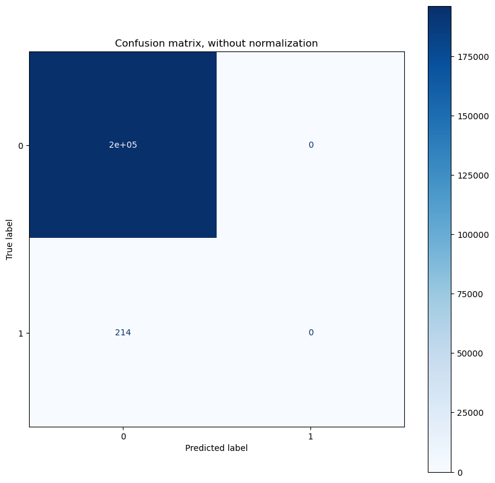

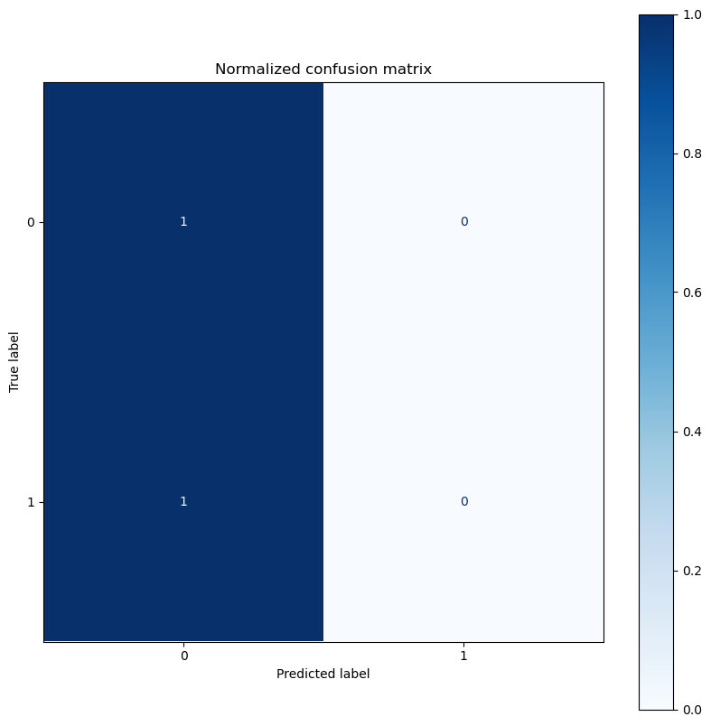

```python
 titles_options = [("Confusion matrix, without normalization", None),
                      ("Normalized confusion matrix", 'true')]
for title, normalize in titles_options:
        fig, ax = plt.subplots(figsize=(10, 10))
        disp = ConfusionMatrixDisplay.from_predictions(y_val, y_pred,
                                                       cmap=plt.cm.Blues,
                                                       normalize=normalize,
                                                       ax=ax)
        ax.set_title(title)
```

```python
clf = Pipeline(steps=[
    ('preprocesador', preprocessor),
    ('clasificador', LogisticRegressionCV(penalty='l2', random_state=0))])
```

```python
clf.fit(x_train, y_train)
```

```
Pipeline(steps=[('preprocesador',
                 ColumnTransformer(transformers=[('num',
                                                  Pipeline(steps=[('imputer',
                                                                   SimpleImputer(strategy='median')),
                                                                  ('scaler',
                                                                   StandardScaler())]),
                                                  Index(['step', 'amount', 'connection_time', 'oldbalanceOrg', 'age',
       'newbalanceOrig', 'user_number', 'user_connections', 'security_alert',
       'oldbalanceDest', 'newbalanceDest', 'type_1', 'type_2', 'type...
       'type_4', 'type_5', 'device_1', 'device_2', 'device_3', 'device_4',
       'zone_1', 'zone_2', 'zone_3', 'zone_4', 'type_of_transactions_1',
       'type_of_transactions_2'],
      dtype='object')),
                                                 ('cat',
                                                  Pipeline(steps=[('imputer',
                                                                   SimpleImputer(fill_value='missing',
                                                                                 strategy='constant')),
                                                                  ('onehot',
                                                                   OneHotEncoder(handle_unknown='ignore'))]),
                                                  Index([], dtype='object'))])),
                ('clasificador', LogisticRegressionCV(random_state=0))])
```

```python
with open('../models/LRlasso.pickle', 'wb') as f:
    pickle.dump(clf, f)
```

```python
load_model('../models/LRlasso.pickle')
```

```
Pipeline(steps=[('preprocesador',
                 ColumnTransformer(transformers=[('num',
                                                  Pipeline(steps=[('imputer',
                                                                   SimpleImputer(strategy='median')),
                                                                  ('scaler',
                                                                   StandardScaler())]),
                                                  Index(['step', 'amount', 'connection_time', 'oldbalanceOrg', 'age',
       'newbalanceOrig', 'user_number', 'user_connections', 'security_alert',
       'oldbalanceDest', 'newbalanceDest', 'type_1', 'type_2', 'type...
       'type_4', 'type_5', 'device_1', 'device_2', 'device_3', 'device_4',
       'zone_1', 'zone_2', 'zone_3', 'zone_4', 'type_of_transactions_1',
       'type_of_transactions_2'],
      dtype='object')),
                                                 ('cat',
                                                  Pipeline(steps=[('imputer',
                                                                   SimpleImputer(fill_value='missing',
                                                                                 strategy='constant')),
                                                                  ('onehot',
                                                                   OneHotEncoder(handle_unknown='ignore'))]),
                                                  Index([], dtype='object'))])),
                ('clasificador', LogisticRegressionCV(random_state=0))])
```

```python
y_pred = clf.predict(x_val)
y_pred_proba = clf.predict_proba(x_val)
evaluate_model(y_val, y_pred, y_pred_proba)
```

```
ROC-AUC score of the model: 0.9870476133281191

F2 Score: 0.7501863562626037

R2 Score: 0.41525137481121077

Accuracy of the model: 0.9993642171223959

Classification report:
              precision    recall  f1-score   support

           0       1.00      1.00      1.00    196394
           1       0.93      0.45      0.61       214

    accuracy                           1.00    196608
   macro avg       0.97      0.72      0.80    196608
weighted avg       1.00      1.00      1.00    196608
```

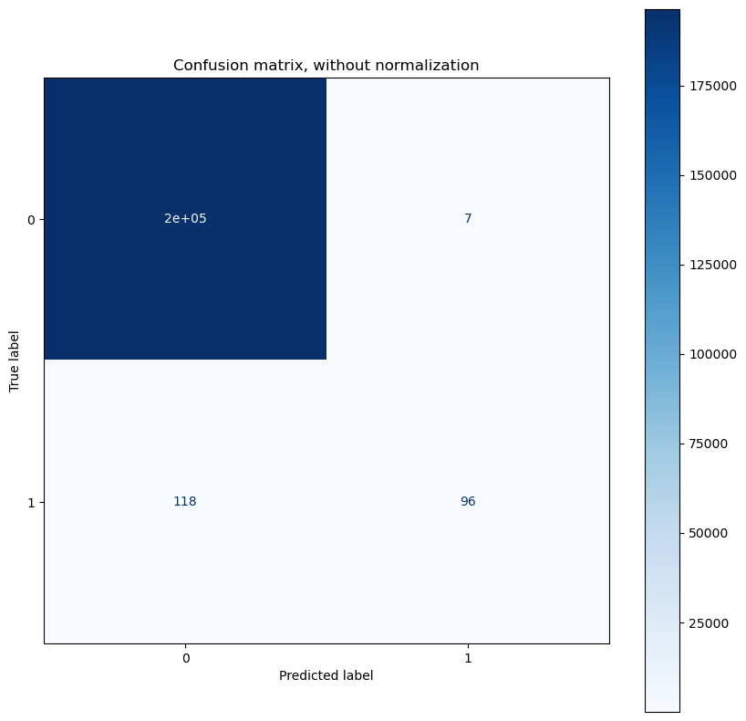

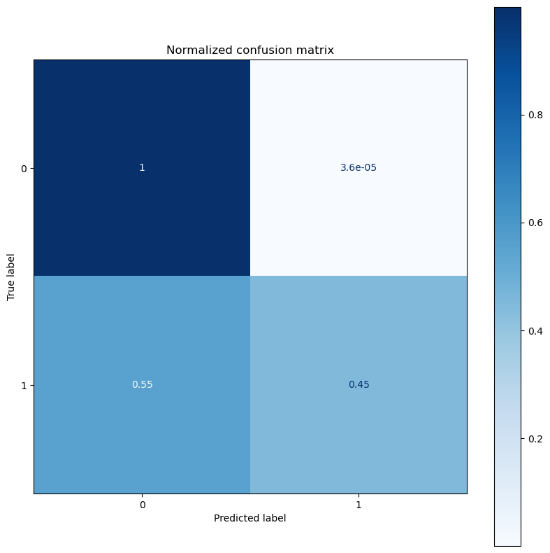

```python
 titles_options = [("Confusion matrix, without normalization", None),
                      ("Normalized confusion matrix", 'true')]
for title, normalize in titles_options:
        fig, ax = plt.subplots(figsize=(10, 10))
        disp = ConfusionMatrixDisplay.from_predictions(y_val, y_pred,
                                                       cmap=plt.cm.Blues,
                                                       normalize=normalize,
                                                       ax=ax)
        ax.set_title(title)
```

### - Generalized Linear Models (LinearRegression)

```python
clf = Pipeline(steps=[
    ('preprocesador', preprocessor),
    ('clasificador', LinearRegression())])
```

```python
clf.fit(x_train, y_train)
```

```
Pipeline(steps=[('preprocesador',
                 ColumnTransformer(transformers=[('num',
                                                  Pipeline(steps=[('imputer',
                                                                   SimpleImputer(strategy='median')),
                                                                  ('scaler',
                                                                   StandardScaler())]),
                                                  Index(['step', 'amount', 'connection_time', 'oldbalanceOrg', 'age',
       'newbalanceOrig', 'user_number', 'user_connections', 'security_alert',
       'oldbalanceDest', 'newbalanceDest', 'type_1', 'type_2', 'type...
       'type_4', 'type_5', 'device_1', 'device_2', 'device_3', 'device_4',
       'zone_1', 'zone_2', 'zone_3', 'zone_4', 'type_of_transactions_1',
       'type_of_transactions_2'],
      dtype='object')),
                                                 ('cat',
                                                  Pipeline(steps=[('imputer',
                                                                   SimpleImputer(fill_value='missing',
                                                                                 strategy='constant')),
                                                                  ('onehot',
                                                                   OneHotEncoder(handle_unknown='ignore'))]),
                                                  Index([], dtype='object'))])),
                ('clasificador', LinearRegression())])
```

```python
with open('../models/GLM.pickle', 'wb') as f:
    pickle.dump(clf, f)
```

```python
load_model('../models/GLM.pickle')
```

```
Pipeline(steps=[('preprocesador',
                 ColumnTransformer(transformers=[('num',
                                                  Pipeline(steps=[('imputer',
                                                                   SimpleImputer(strategy='median')),
                                                                  ('scaler',
                                                                   StandardScaler())]),
                                                  Index(['step', 'amount', 'connection_time', 'oldbalanceOrg', 'age',
       'newbalanceOrig', 'user_number', 'user_connections', 'security_alert',
       'oldbalanceDest', 'newbalanceDest', 'type_1', 'type_2', 'type...
       'type_4', 'type_5', 'device_1', 'device_2', 'device_3', 'device_4',
       'zone_1', 'zone_2', 'zone_3', 'zone_4', 'type_of_transactions_1',
       'type_of_transactions_2'],
      dtype='object')),
                                                 ('cat',
                                                  Pipeline(steps=[('imputer',
                                                                   SimpleImputer(fill_value='missing',
                                                                                 strategy='constant')),
                                                                  ('onehot',
                                                                   OneHotEncoder(handle_unknown='ignore'))]),
                                                  Index([], dtype='object'))])),
                ('clasificador', LinearRegression())])
```

```python
ypred = clf.predict(x_val)

rmse = mean_squared_error(
        y_true  = y_val,
        y_pred  = y_pred,
        squared = False
       )
print("")
print(f"El error (rmse) del test es: {rmse}")
print(f'El coeficiente de determinacion (R2) del test es de : {r2_score(y_val, y_pred)}\n')
```

```
El error (rmse) del test es: 0.025214735326871202
El coeficiente de determinacion (R2) del test es de : 0.41525137481121077
```

### - Support Vector Machine (SVM)

```python
clf = Pipeline(steps=[
    ('preprocesador', preprocessor),
    ('clasificador', SVC(probability = True, random_state = 0))])
```

```python
clf.fit(x_train, y_train)
```

```
Pipeline(steps=[('preprocesador',
                 ColumnTransformer(transformers=[('num',
                                                  Pipeline(steps=[('imputer',
                                                                   SimpleImputer(strategy='median')),
                                                                  ('scaler',
                                                                   StandardScaler())]),
                                                  Index(['step', 'amount', 'connection_time', 'oldbalanceOrg', 'age',
       'newbalanceOrig', 'user_number', 'user_connections', 'security_alert',
       'oldbalanceDest', 'newbalanceDest', 'type_1', 'type_2', 'type...
       'type_4', 'type_5', 'device_1', 'device_2', 'device_3', 'device_4',
       'zone_1', 'zone_2', 'zone_3', 'zone_4', 'type_of_transactions_1',
       'type_of_transactions_2'],
      dtype='object')),
                                                 ('cat',
                                                  Pipeline(steps=[('imputer',
                                                                   SimpleImputer(fill_value='missing',
                                                                                 strategy='constant')),
                                                                  ('onehot',
                                                                   OneHotEncoder(handle_unknown='ignore'))]),
                                                  Index([], dtype='object'))])),
                ('clasificador', SVC(probability=True, random_state=0))])
```

```python
with open('../models/SVM.pickle', 'wb') as f:
    pickle.dump(clf, f)
```

```python
load_model('../models/SVM.pickle')
```

```
Pipeline(steps=[('preprocesador',
                 ColumnTransformer(transformers=[('num',
                                                  Pipeline(steps=[('imputer',
                                                                   SimpleImputer(strategy='median')),
                                                                  ('scaler',
                                                                   StandardScaler())]),
                                                  Index(['step', 'amount', 'connection_time', 'oldbalanceOrg', 'age',
       'newbalanceOrig', 'user_number', 'user_connections', 'security_alert',
       'oldbalanceDest', 'newbalanceDest', 'type_1', 'type_2', 'type...
       'type_4', 'type_5', 'device_1', 'device_2', 'device_3', 'device_4',
       'zone_1', 'zone_2', 'zone_3', 'zone_4', 'type_of_transactions_1',
       'type_of_transactions_2'],
      dtype='object')),
                                                 ('cat',
                                                  Pipeline(steps=[('imputer',
                                                                   SimpleImputer(fill_value='missing',
                                                                                 strategy='constant')),
                                                                  ('onehot',
                                                                   OneHotEncoder(handle_unknown='ignore'))]),
                                                  Index([], dtype='object'))])),
                ('clasificador', SVC(probability=True, random_state=0))])
```

```python
y_pred = clf.predict(x_val)
y_pred_proba = clf.predict_proba(x_val)
evaluate_model(y_val,y_pred,y_pred_proba)
```

```
ROC-AUC score of the model: 0.9496555369955818

F2 Score: 0.6349725658595713

R2 Score: 0.21877583674777756

Accuracy of the model: 0.9991505940755209

Classification report:
              precision    recall  f1-score   support

           0       1.00      1.00      1.00    196394
           1       0.96      0.23      0.37       214

    accuracy                           1.00    196608
   macro avg       0.98      0.61      0.68    196608
weighted avg       1.00      1.00      1.00    196608
```

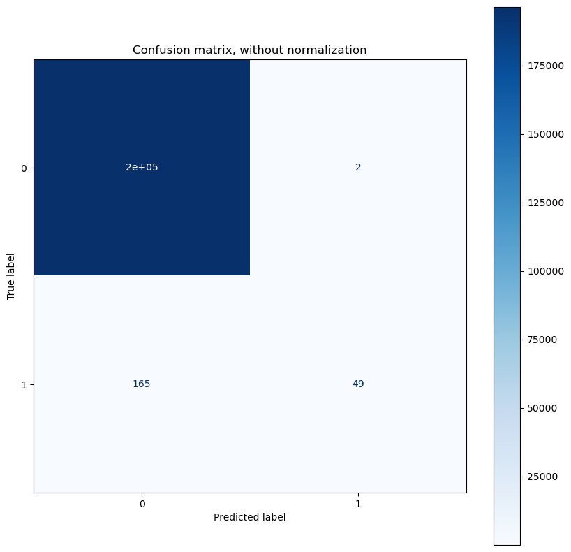

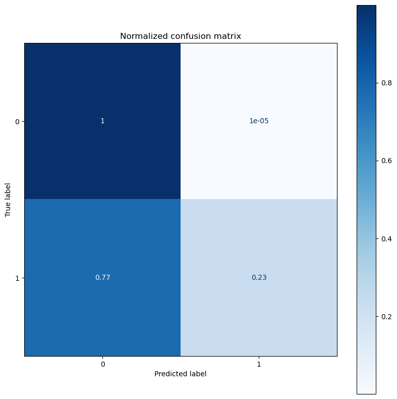

```python
 titles_options = [("Confusion matrix, without normalization", None),
                      ("Normalized confusion matrix", 'true')]
for title, normalize in titles_options:
        fig, ax = plt.subplots(figsize=(10, 10))
        disp = ConfusionMatrixDisplay.from_predictions(y_val, y_pred,
                                                       cmap=plt.cm.Blues,
                                                       normalize=normalize,
                                                       ax=ax)
        ax.set_title(title)
```

### - Random Forest

```python
clf = Pipeline(steps=[
    ('preprocesador', preprocessor),
    ('clasificador', RandomForestClassifier(random_state=0))])
```

```python
clf.fit(x_train, y_train)
```

```
Pipeline(steps=[('preprocesador',
                 ColumnTransformer(transformers=[('num',
                                                  Pipeline(steps=[('imputer',
                                                                   SimpleImputer(strategy='median')),
                                                                  ('scaler',
                                                                   StandardScaler())]),
                                                  Index(['step', 'amount', 'connection_time', 'oldbalanceOrg', 'age',
       'newbalanceOrig', 'user_number', 'user_connections', 'security_alert',
       'oldbalanceDest', 'newbalanceDest', 'type_1', 'type_2', 'type...
       'type_4', 'type_5', 'device_1', 'device_2', 'device_3', 'device_4',
       'zone_1', 'zone_2', 'zone_3', 'zone_4', 'type_of_transactions_1',
       'type_of_transactions_2'],
      dtype='object')),
                                                 ('cat',
                                                  Pipeline(steps=[('imputer',
                                                                   SimpleImputer(fill_value='missing',
                                                                                 strategy='constant')),
                                                                  ('onehot',
                                                                   OneHotEncoder(handle_unknown='ignore'))]),
                                                  Index([], dtype='object'))])),
                ('clasificador', RandomForestClassifier(random_state=0))])
```

```python
with open('../models/RandomForest.pickle', 'wb') as f:
    pickle.dump(clf, f)
```

```python
load_model('../models/RandomForest.pickle')
```

```
Pipeline(steps=[('preprocesador',
                 ColumnTransformer(transformers=[('num',
                                                  Pipeline(steps=[('imputer',
                                                                   SimpleImputer(strategy='median')),
                                                                  ('scaler',
                                                                   StandardScaler())]),
                                                  Index(['step', 'amount', 'connection_time', 'oldbalanceOrg', 'age',
       'newbalanceOrig', 'user_number', 'user_connections', 'security_alert',
       'oldbalanceDest', 'newbalanceDest', 'type_1', 'type_2', 'type...
       'type_4', 'type_5', 'device_1', 'device_2', 'device_3', 'device_4',
       'zone_1', 'zone_2', 'zone_3', 'zone_4', 'type_of_transactions_1',
       'type_of_transactions_2'],
      dtype='object')),
                                                 ('cat',
                                                  Pipeline(steps=[('imputer',
                                                                   SimpleImputer(fill_value='missing',
                                                                                 strategy='constant')),
                                                                  ('onehot',
                                                                   OneHotEncoder(handle_unknown='ignore'))]),
                                                  Index([], dtype='object'))])),
                ('clasificador', RandomForestClassifier(random_state=0))])
```

```python
y_pred = clf.predict(x_val)
y_pred_proba = clf.predict_proba(x_val)
evaluate_model(y_val,y_pred,y_pred_proba)
```

```
ROC-AUC score of the model: 0.9758948348061339

F2 Score: 0.9138022400544693

R2 Score: 0.7894904949320358

Accuracy of the model: 0.9997711181640625

Classification report:
              precision    recall  f1-score   support

           0       1.00      1.00      1.00    196394
           1       0.99      0.79      0.88       214

    accuracy                           1.00    196608
   macro avg       1.00      0.90      0.94    196608
weighted avg       1.00      1.00      1.00    196608
```

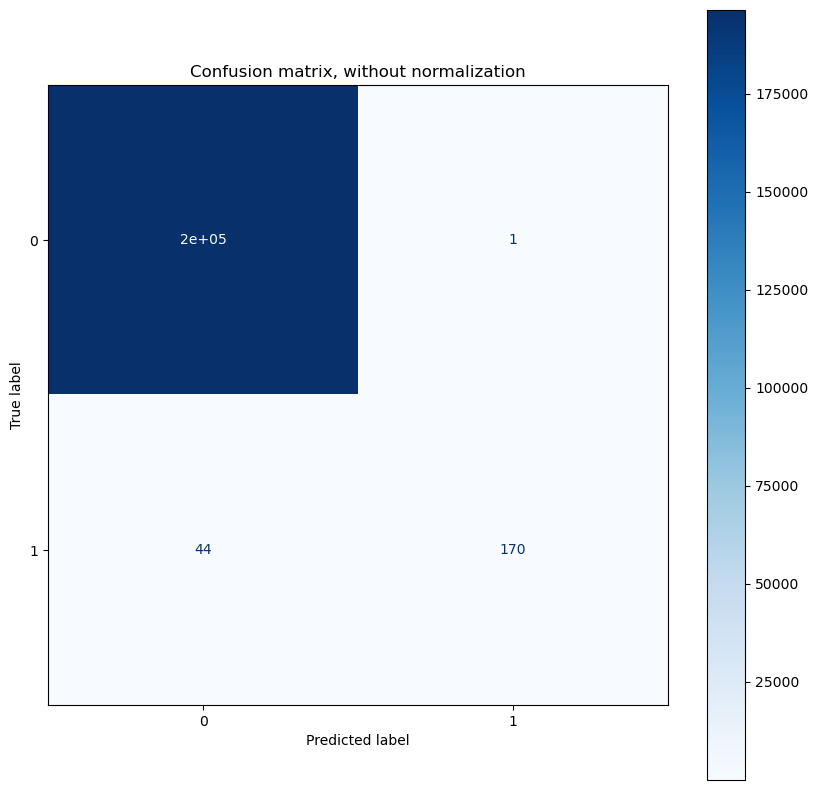

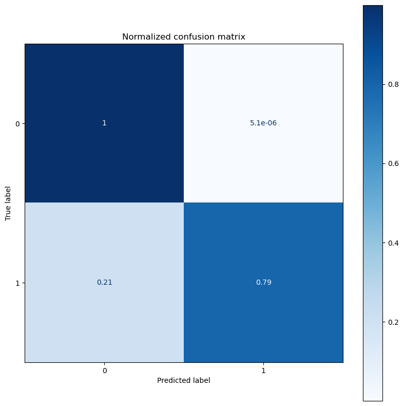

```python
 titles_options = [("Confusion matrix, without normalization", None),
                      ("Normalized confusion matrix", 'true')]
for title, normalize in titles_options:
        fig, ax = plt.subplots(figsize=(10, 10))
        disp = ConfusionMatrixDisplay.from_predictions(y_val, y_pred,
                                                       cmap=plt.cm.Blues,
                                                       normalize=normalize,
                                                       ax=ax)
        ax.set_title(title)
```

### - XGBoost

```python
clf = Pipeline(steps=[
    ('preprocesador', preprocessor),
    ('clasificador', XGBClassifier(random_state=0))])
```

```python
clf.fit(x_train, y_train)
```

```
Pipeline(steps=[('preprocesador',
                 ColumnTransformer(transformers=[('num',
                                                  Pipeline(steps=[('imputer',
                                                                   SimpleImputer(strategy='median')),
                                                                  ('scaler',
                                                                   StandardScaler())]),
                                                  Index(['step', 'amount', 'connection_time', 'oldbalanceOrg', 'age',
       'newbalanceOrig', 'user_number', 'user_connections', 'security_alert',
       'oldbalanceDest', 'newbalanceDest', 'type_1', 'type_2', 'type...
                               feature_types=None, gamma=0, gpu_id=-1,
                               grow_policy='depthwise', importance_type=None,
                               interaction_constraints='',
                               learning_rate=0.300000012, max_bin=256,
                               max_cat_threshold=64, max_cat_to_onehot=4,
                               max_delta_step=0, max_depth=6, max_leaves=0,
                               min_child_weight=1, missing=nan,
                               monotone_constraints='()', n_estimators=100,
                               n_jobs=0, num_parallel_tree=1, predictor='auto',
                               random_state=0, ...))])
```

```python
with open('../models/XGBoost.pickle', 'wb') as f:
    pickle.dump(clf, f)
```

```python
load_model('../models/XGBoost.pickle')
```

```
Pipeline(steps=[('preprocesador',
                 ColumnTransformer(transformers=[('num',
                                                  Pipeline(steps=[('imputer',
                                                                   SimpleImputer(strategy='median')),
                                                                  ('scaler',
                                                                   StandardScaler())]),
                                                  Index(['step', 'amount', 'connection_time', 'oldbalanceOrg', 'age',
       'newbalanceOrig', 'user_number', 'user_connections', 'security_alert',
       'oldbalanceDest', 'newbalanceDest', 'type_1', 'type_2', 'type...
                               feature_types=None, gamma=0, gpu_id=-1,
                               grow_policy='depthwise', importance_type=None,
                               interaction_constraints='',
                               learning_rate=0.300000012, max_bin=256,
                               max_cat_threshold=64, max_cat_to_onehot=4,
                               max_delta_step=0, max_depth=6, max_leaves=0,
                               min_child_weight=1, missing=nan,
                               monotone_constraints='()', n_estimators=100,
                               n_jobs=0, num_parallel_tree=1, predictor='auto',
                               random_state=0, ...))])
```

```python
y_pred = clf.predict(x_val)
y_pred_proba = clf.predict_proba(x_val)
evaluate_model(y_val,y_pred,y_pred_proba)
```

```
ROC-AUC score of the model: 0.9993311414142789

F2 Score: 0.9383266739988627

R2 Score: 0.85030435195167

Accuracy of the model: 0.9998372395833334

Classification report:
              precision    recall  f1-score   support

           0       1.00      1.00      1.00    196394
           1       1.00      0.85      0.92       214

    accuracy                           1.00    196608
   macro avg       1.00      0.93      0.96    196608
weighted avg       1.00      1.00      1.00    196608
```

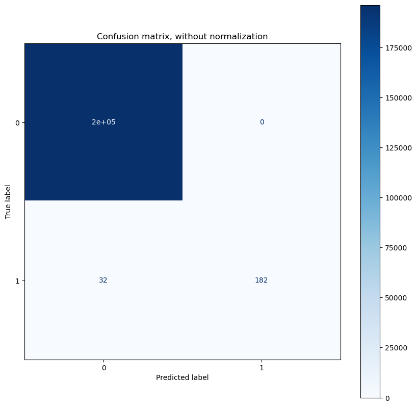

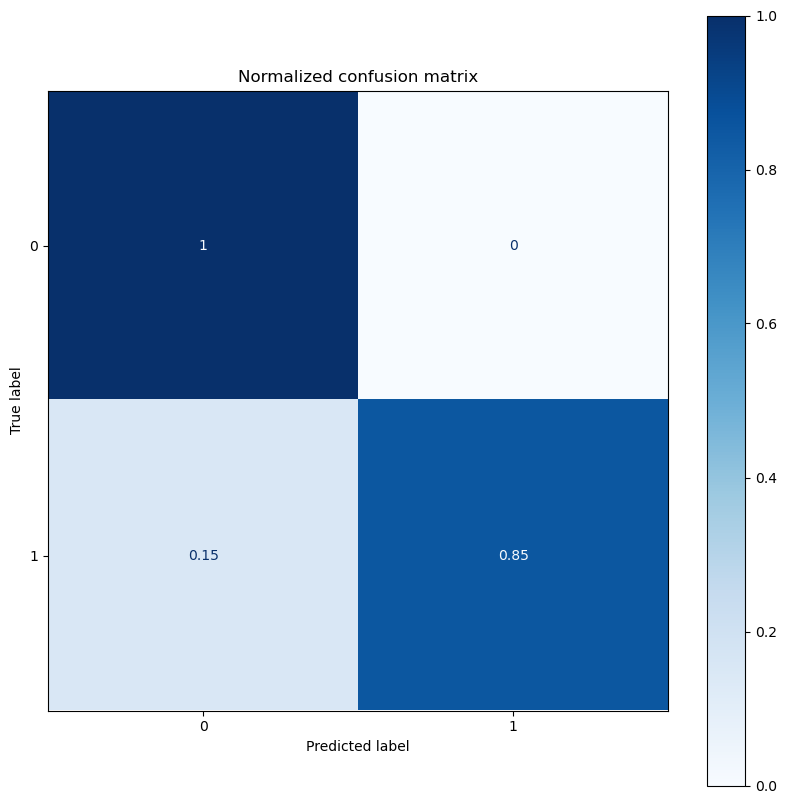

```python
 titles_options = [("Confusion matrix, without normalization", None),
                      ("Normalized confusion matrix", 'true')]
for title, normalize in titles_options:
        fig, ax = plt.subplots(figsize=(10, 10))
        disp = ConfusionMatrixDisplay.from_predictions(y_val, y_pred,
                                                       cmap=plt.cm.Blues,
                                                       normalize=normalize,
                                                       ax=ax)
        ax.set_title(title)
```

```python
import shap

explainer = shap.TreeExplainer(best_xgb.best_estimator_)
shap_values = explainer.shap_values(xtest)
shap.summary_plot(shap_values, xtest)
```

[output not shown]

### - LightGBM

```python
clf = Pipeline(steps=[
    ('preprocesador', preprocessor),
    ('clasificador', lgb.LGBMClassifier(random_state=0))])
```

```python
clf.fit(x_train, y_train)
```

```
Pipeline(steps=[('preprocesador',
                 ColumnTransformer(transformers=[('num',
                                                  Pipeline(steps=[('imputer',
                                                                   SimpleImputer(strategy='median')),
                                                                  ('scaler',
                                                                   StandardScaler())]),
                                                  Index(['step', 'amount', 'connection_time', 'oldbalanceOrg', 'age',
       'newbalanceOrig', 'user_number', 'user_connections', 'security_alert',
       'oldbalanceDest', 'newbalanceDest', 'type_1', 'type_2', 'type...
       'type_4', 'type_5', 'device_1', 'device_2', 'device_3', 'device_4',
       'zone_1', 'zone_2', 'zone_3', 'zone_4', 'type_of_transactions_1',
       'type_of_transactions_2'],
      dtype='object')),
                                                 ('cat',
                                                  Pipeline(steps=[('imputer',
                                                                   SimpleImputer(fill_value='missing',
                                                                                 strategy='constant')),
                                                                  ('onehot',
                                                                   OneHotEncoder(handle_unknown='ignore'))]),
                                                  Index([], dtype='object'))])),
                ('clasificador', LGBMClassifier(random_state=0))])
```

```python
with open('../models/LightGBM.pickle', 'wb') as f:
    pickle.dump(clf, f)
```

```python
load_model('../models/LightGBM.pickle')
```

```
Pipeline(steps=[('preprocesador',
                 ColumnTransformer(transformers=[('num',
                                                  Pipeline(steps=[('imputer',
                                                                   SimpleImputer(strategy='median')),
                                                                  ('scaler',
                                                                   StandardScaler())]),
                                                  Index(['step', 'amount', 'connection_time', 'oldbalanceOrg', 'age',
       'newbalanceOrig', 'user_number', 'user_connections', 'security_alert',
       'oldbalanceDest', 'newbalanceDest', 'type_1', 'type_2', 'type...
       'type_4', 'type_5', 'device_1', 'device_2', 'device_3', 'device_4',
       'zone_1', 'zone_2', 'zone_3', 'zone_4', 'type_of_transactions_1',
       'type_of_transactions_2'],
      dtype='object')),
                                                 ('cat',
                                                  Pipeline(steps=[('imputer',
                                                                   SimpleImputer(fill_value='missing',
                                                                                 strategy='constant')),
                                                                  ('onehot',
                                                                   OneHotEncoder(handle_unknown='ignore'))]),
                                                  Index([], dtype='object'))])),
                ('clasificador', LGBMClassifier(random_state=0))])
```

```python
y_pred = clf.predict(x_val)
y_pred_proba = clf.predict_proba(x_val)
evaluate_model(y_val,y_pred,y_pred_proba)
```

```
ROC-AUC score of the model: 0.6193162367009899

F2 Score: 0.6121351684615709

R2 Score: -0.6279401725255893

Accuracy of the model: 0.99822998046875

Classification report:
              precision    recall  f1-score   support

           0       1.00      1.00      1.00    196394
           1       0.21      0.23      0.22       214

    accuracy                           1.00    196608
   macro avg       0.61      0.61      0.61    196608
weighted avg       1.00      1.00      1.00    196608
```

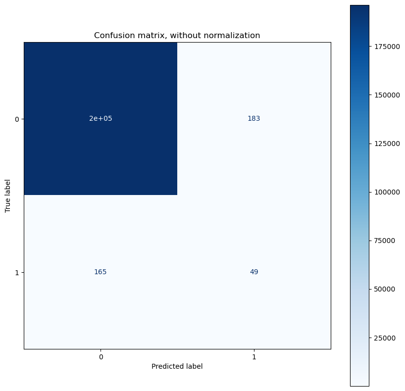

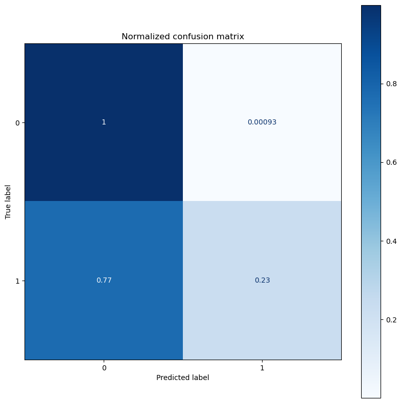

```python
 titles_options = [("Confusion matrix, without normalization", None),
                      ("Normalized confusion matrix", 'true')]
for title, normalize in titles_options:
        fig, ax = plt.subplots(figsize=(10, 10))
        disp = ConfusionMatrixDisplay.from_predictions(y_val, y_pred,
                                                       cmap=plt.cm.Blues,
                                                       normalize=normalize,
                                                       ax=ax)
        ax.set_title(title)
```

### - AdaBoost

```python
clf = Pipeline(steps=[
    ('preprocesador', preprocessor),
    ('clasificador', AdaBoostClassifier(random_state=0))])
```

```python
clf.fit(x_train, y_train)
```

```
Pipeline(steps=[('preprocesador',
                 ColumnTransformer(transformers=[('num',
                                                  Pipeline(steps=[('imputer',
                                                                   SimpleImputer(strategy='median')),
                                                                  ('scaler',
                                                                   StandardScaler())]),
                                                  Index(['step', 'amount', 'connection_time', 'oldbalanceOrg', 'age',
       'newbalanceOrig', 'user_number', 'user_connections', 'security_alert',
       'oldbalanceDest', 'newbalanceDest', 'type_1', 'type_2', 'type...
       'type_4', 'type_5', 'device_1', 'device_2', 'device_3', 'device_4',
       'zone_1', 'zone_2', 'zone_3', 'zone_4', 'type_of_transactions_1',
       'type_of_transactions_2'],
      dtype='object')),
                                                 ('cat',
                                                  Pipeline(steps=[('imputer',
                                                                   SimpleImputer(fill_value='missing',
                                                                                 strategy='constant')),
                                                                  ('onehot',
                                                                   OneHotEncoder(handle_unknown='ignore'))]),
                                                  Index([], dtype='object'))])),
                ('clasificador', AdaBoostClassifier(random_state=0))])
```

```python
with open('../models/AdaBoost.pickle', 'wb') as f:
    pickle.dump(clf, f)
```

```python
load_model('../models/AdaBoost.pickle')
```

```
Pipeline(steps=[('preprocesador',
                 ColumnTransformer(transformers=[('num',
                                                  Pipeline(steps=[('imputer',
                                                                   SimpleImputer(strategy='median')),
                                                                  ('scaler',
                                                                   StandardScaler())]),
                                                  Index(['step', 'amount', 'connection_time', 'oldbalanceOrg', 'age',
       'newbalanceOrig', 'user_number', 'user_connections', 'security_alert',
       'oldbalanceDest', 'newbalanceDest', 'type_1', 'type_2', 'type...
       'type_4', 'type_5', 'device_1', 'device_2', 'device_3', 'device_4',
       'zone_1', 'zone_2', 'zone_3', 'zone_4', 'type_of_transactions_1',
       'type_of_transactions_2'],
      dtype='object')),
                                                 ('cat',
                                                  Pipeline(steps=[('imputer',
                                                                   SimpleImputer(fill_value='missing',
                                                                                 strategy='constant')),
                                                                  ('onehot',
                                                                   OneHotEncoder(handle_unknown='ignore'))]),
                                                  Index([], dtype='object'))])),
                ('clasificador', AdaBoostClassifier(random_state=0))])
```

```python
y_pred = clf.predict(x_val)
y_pred_proba = clf.predict_proba(x_val)
evaluate_model(y_val,y_pred,y_pred_proba)
```

```
ROC-AUC score of the model: 0.9955585063175026

F2 Score: 0.8272340135134899

R2 Score: 0.5743030008625614

Accuracy of the model: 0.9995371500651041

Classification report:
              precision    recall  f1-score   support

           0       1.00      1.00      1.00    196394
           1       0.95      0.61      0.74       214

    accuracy                           1.00    196608
   macro avg       0.97      0.80      0.87    196608
weighted avg       1.00      1.00      1.00    196608
```

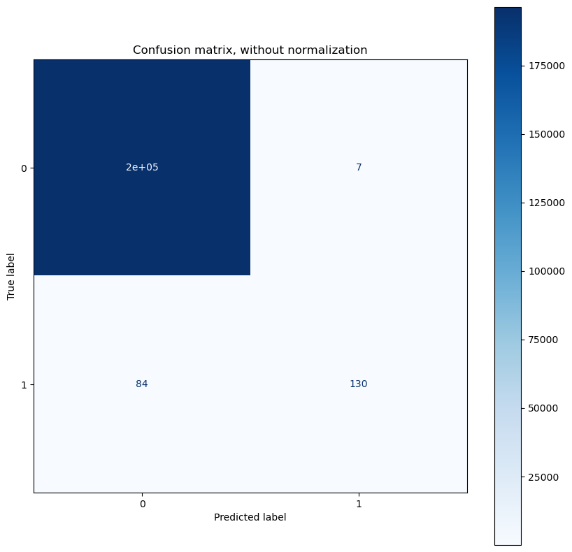

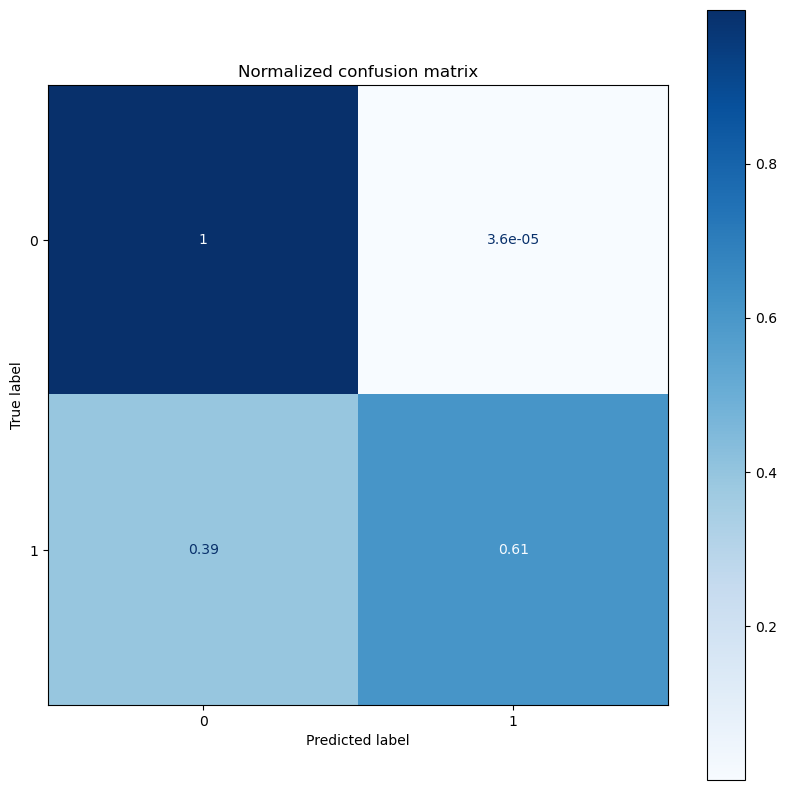

```python
 titles_options = [("Confusion matrix, without normalization", None),
                      ("Normalized confusion matrix", 'true')]
for title, normalize in titles_options:
        fig, ax = plt.subplots(figsize=(10, 10))
        disp = ConfusionMatrixDisplay.from_predictions(y_val, y_pred,
                                                       cmap=plt.cm.Blues,
                                                       normalize=normalize,
                                                       ax=ax)
        ax.set_title(title)
```